# 20260119 PPX1,PPN1 reentry analysis

Bin He

2026-01-19, updated 2026-02-08

```r
require(tidyverse)
library(gcplyr)
require(cowplot)
```

```r
# Set ggplot theme
old = theme_set(theme_bw(base_size = 14))
```

## Goal

Determine the lag times of PPX1 and PPN1 KO strains re-entering growth from -Pi starvation media into phosphate-replete media.

## Data

### Import growth curve data

Experiment on 2026-01-09

```r
# using the read_wides() function from gcplyr to read in the data
dat_wide <- read_wides(files = "../input/20260109_PPX1_PPN1_reentry.csv") |>
  # convert time into proper formats
  mutate(Time = time_length(hms(Time), unit = "hour"))

# Transform our data to be tidy-shaped
dat_tidy <-
  trans_wide_to_tidy(wides = dat_wide, id_cols = c("file", "Time")) %>%
  #Set up the Well column so they plot in the correct order
  mutate(Well = factor(Well,
                       levels = paste0(rep(LETTERS[1:8], each = 12), 1:12)))

# Convert time into hours
#dat_tidy$Time <- as.numeric(PPKOdata_tidy$Time)/3600
```

### Exclude empty wells

```r
tmp <- dat_tidy %>%
  group_by(Well) %>%
  summarize(Max = max(Measurements, na.rm = TRUE))
empty_wells = tmp$Well[tmp$Max < 0.12]
sprintf("The following wells are empty: %s", paste(empty_wells, collapse = ", "))
```

```
[1] "The following wells are empty: A1, A2, A3, A4, A5, A6, A7, A8, A9, A10, A11, A12, B1, B6, B11, B12, C1, C6, C11, C12, D1, D6, D11, D12, E1, E6, E11, E12, F1, F6, F11, F12, G1, G6, G11, G12, H1, H6, H11, H12"
```

```r
dat_filtered <- filter(dat_tidy, !(Well %in% empty_wells))
```

### Import design file

```r
meta_info <- read_csv("../input/20260109_plate_layout.csv")
```

### Load example data from `gcplyr`

This helps us to see whether the functions we wrote work properly by checking them against the example dataset and the expected results based on the package author’s [vignettes](https://mikeblazanin.github.io/gcplyr/articles/analyze.html#lag)

```r
# This code was previously explained
# Here we're re-running it so it's available for us to work with
example_tidydata <- trans_wide_to_tidy(example_widedata_noiseless,
                                       id_cols = "Time")
example_design <- make_design(
  pattern_split = ",", nrows = 8, ncols = 12,
  "Bacteria_strain" = make_designpattern(
    values = paste("Strain", 1:48),
    rows = 1:8, cols = 1:6, pattern = 1:48, byrow = TRUE),
  "Bacteria_strain" = make_designpattern(
    values = paste("Strain", 1:48),
    rows = 1:8, cols = 7:12, pattern = 1:48, byrow = TRUE),
  "Phage" = make_designpattern(
    values = c("No Phage"), rows = 1:8, cols = 1:6, pattern = "1"),
  "Phage" = make_designpattern(
    values = c("Phage Added"), rows = 1:8, cols = 7:12, pattern = "1"))
ex_dat_mrg <- merge_dfs(example_tidydata, example_design)
ex_dat_mrg$Well <-
  factor(ex_dat_mrg$Well,
         levels = paste(rep(LETTERS[1:8], each = 12), 1:12, sep = ""))
ex_dat_mrg$Time <- ex_dat_mrg$Time/3600 #Convert time to hours
ex_dat_mrg <-
  mutate(group_by(ex_dat_mrg, Well, Bacteria_strain, Phage),
         Deriv = calc_deriv(x = Time, y = Measurements),
         percap_deriv = calc_deriv(x = Time, y = Measurements,
                                        percapita = TRUE, blank = 0,
                                        window_width_n = 5, trans_y = "log"),
         doub_time = doubling_time(y = percap_deriv))
sample_wells <- c("A1", "F1", "F10", "E11")
# Drop unneeded columns (optional, but makes things cleaner)
ex_dat_mrg <- dplyr::select(ex_dat_mrg,
                            Time, Well, Measurements, Bacteria_strain, Phage,
                            Deriv, percap_deriv)

# calculate lag time etc.
ex_dat_mrg_sum <-
  summarize(group_by(ex_dat_mrg, Bacteria_strain, Phage, Well),
            lag_time = lag_time(y = Measurements, x = Time,
                                deriv = percap_deriv, blank = 0),
            max_percap = max_gc(percap_deriv),
            max_percap_time = Time[which_max_gc(percap_deriv)],
            max_percap_dens = Measurements[which_max_gc(percap_deriv)],
            min_dens = min_gc(Measurements))
```

## Analysis

### EDA

1. growth curve as line plot

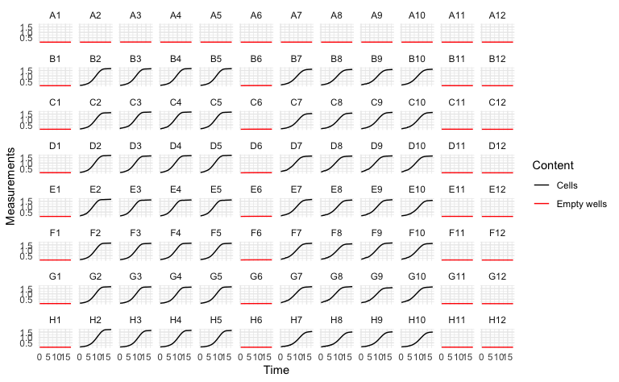

```r
ggplot(data = dat_tidy, aes(x = Time, y = Measurements)) +
  geom_line(aes(color = Well %in% empty_wells)) +
  scale_color_manual("Content", values = c("black", "red"),
                     labels = c("Cells", "Empty wells")) +
  facet_wrap(~Well, nrow = 8, ncol = 12) +
  theme_minimal()
```

2. Calculate derivatives

```r
# use column 6 as the blank since it is in between the two sets of samples
blank_wells <- paste0(LETTERS[1:8], '6')
blank_value <- dat_tidy |> filter(Well %in% empty_wells) |>
  pull(Measurements) |> mean(na.rm = TRUE)

dat_deriv <- dat_filtered %>%
  group_by(Well) %>%
  mutate(
    # plain derivative
    Deriv = calc_deriv(x = Time, y = Measurements, window_width_n = 5),
    percap_deriv = calc_deriv(x = Time, y = Measurements,
                              percapita = TRUE,
                              blank = blank_value,
                              window_width_n = 5,
                              trans_y = "log")
  )

dat_merged <- left_join(meta_info, dat_deriv, by = "Well")
```

Plot plain derivative

```
ggplot(plain_deriv, aes(x = Time, y = Deriv)) +
  geom_line() +
  facet_wrap(~Well, nrow = 8, ncol = 7) +
  theme_minimal_grid(font_size = 10)
```

Per capita derivative

```
ggplot(per_cap_deriv, aes(x = Time, y = percap_deriv)) +
  geom_line() +
  facet_wrap(~Well, nrow = 8, ncol = 7, scales = "free_y") +
  theme_minimal_grid(font_size = 10) +
  theme(axis.text.y = element_blank())
```

### Lag time and other summary stats calculation

```r
dat_sum <- dat_deriv %>%
  group_by(Well) %>%
  summarize(
    #min_dens = min_gc(Measurements, na.rm = TRUE)
    lag_time = lag_time(x = Time, y = Measurements,
                        deriv = percap_deriv,
                        blank = blank_value),
    max_percap = max_gc(percap_deriv),
    max_percap_time = Time[which_max_gc(percap_deriv)],
    max_percap_dens = Measurements[which_max_gc(percap_deriv)],
    min_dens = min_gc(Measurements)
  ) %>%
  full_join(meta_info, by = "Well") %>%
  select(Well, Genotype, Group, everything())
```

### Diagnostic plot

Build a diagnostic plot function

```r
my_diag_plot <- function(df, df.sum, well){
  # df is the data frame containing the data
  # df.sum contains the per well estimates calculated from the raw data
  # this function is aimed at one well of data, specified by "well"
  # check to see if the well number is valid
  if(!well %in% df$Well){
    stop(paste(well, "is not a valid well", sep = " "))
  }

  # subset the df
  dat <- filter(df, Well == well)
  # extract the estimates
  par <- filter(df.sum, Well == well)

  # for overlaying the derivatives on the plot,
  # we will calculate a scaling factor
  tmp <- dat %>% summarize(
    min_OD = min_gc(Measurements), max_OD = max_gc(Measurements),
    min_deriv = min_gc(Deriv), max_deriv = max_gc(Deriv),
    rng_OD = max_OD - min_OD,
    rng_deriv = max_deriv - min_deriv,
    sf_deriv = rng_OD / rng_deriv,
    min_logOD = min_gc(log(Measurements)), max_logOD = max_gc(log(Measurements)),
    min_percap_deriv = min_gc(percap_deriv), max_percap_deriv = max_gc(percap_deriv),
    rng_logOD = max_logOD - min_logOD,
    rng_percap_deriv = max_percap_deriv - min_percap_deriv,
    sf_percap_deriv = rng_logOD / rng_percap_deriv
  )

  # make the linear growth curve plot
  p1 <- dat %>%
    mutate(
      scaled_deriv = (Deriv - tmp$min_deriv)*tmp$sf_deriv + tmp$min_OD
    ) %>%
    ggplot(aes(x = Time, y = Measurements)) + geom_point(size = 0.4) +
    geom_line() +
    geom_line(aes(x = Time, y = scaled_deriv), color = "blue", linetype = 2) +
    ylab("OD")

  # make the semi-log plot
  p2 <- dat %>%
    mutate(
      scaled_percap_deriv = (percap_deriv-tmp$min_percap_deriv)*tmp$sf_percap_deriv +
        tmp$min_logOD
    ) %>%
    ggplot(aes(x = Time, y = log(Measurements))) + geom_point() + geom_line() +
    geom_line(aes(x = Time, y = scaled_percap_deriv),
              color = "blue", linetype = 2) +
    geom_abline(
      data = par,
      color = "red",
      aes(slope = max_percap,
          intercept = log(max_percap_dens) - max_percap * max_percap_time)
    ) +
    geom_vline(data = par,
               aes(xintercept = lag_time), lty = 2) +
    geom_hline(data = par,
               aes(yintercept = log(min_dens))) +
    ylab("log OD")
  # draw the derivative and per_capita_derivative

  plot_grid(p1, p2, nrow = 2)
}
```

```r
problem_wells <- c("C10", "D7", "E9", "F8")
tmp <- filter(lag_time, Well %in% problem_wells)
```

```
Error in UseMethod("filter") :
  no applicable method for 'filter' applied to an object of class "function"
```

# Here I am trying to use “smooth” to adjust try to remove noise

#After I smooth the data I need to figure out what derivative value to use

# I want to see what the effects of the different derivaitve windows are

```r
wells_of_interest <- c("D7", "D8", "H8", "H10")

PPKOdata_deriv_wide <-
  PPKOdata_deriv_multi %>%
  filter(Well %in% wells_of_interest) %>%
  pivot_longer(
    cols = starts_with("derivpercap_"),
    names_to = "window_width_n",
    names_prefix = "derivpercap_",
    values_to = "derivpercap"
  )
ggplot(
  data = PPKOdata_deriv_wide,
  aes(x = Time, y = derivpercap)
) +
  geom_line(
    aes(color = window_width_n),
    linewidth = 1,
    alpha = 0.75
  ) +
  facet_wrap(~ Well, scales = "free_y") +
  scale_color_grey(
    start = 0.7,
    end = 0.1,
    name = "window width"
  ) +
  ylim(NA, 5) +
  labs(
    title = "Per-capita derivative at multiple smoothing levels",
    y = "Per-capita growth rate"
  ) +
  theme_bw()
```

# I want a closer look so I look at only the first 6 hours

```r
PPKOdata_deriv_6h <-
  PPKOdata_deriv_wide %>%
  filter(Time <= 6)
ggplot(
  PPKOdata_deriv_6h,
  aes(x = Time, y = derivpercap, color = window_width_n)
) +
  geom_line(linewidth = 1, alpha = 0.75) +
  facet_wrap(~ Well, scales = "free_y") +
  scale_color_grey(
    start = 0.7,
    end = 0.1,
    name = "window width"
  ) +
  labs(
    title = "Per-capita growth rate (first 6 hours)",
    y = "Per-capita derivative",
    x = "Time (hours)"
  ) +
  theme_bw()
```

#now I try to replot growth curves and lag times using window width of 5

```r
PPKOdata_final <-
  PPKOdata_merged %>%
  group_by(Well) %>%
  mutate(
    percap_deriv = calc_deriv(
      x = Time,
      y = meas_smooth,
      percapita = TRUE,
      blank = 0,
      window_width_n = 5
    )
  ) %>%
  ungroup()

ggplot(data = PPKOdata_final, aes(x = Time, y = meas_smooth)) +
  geom_line() +
  facet_wrap(~Well, nrow = 8, ncol = 12)
```

```r
PPKOdata_sum_smooth <- summarize(
  group_by(PPKOdata_merged, Well),
  lag_time = lag_time(x = Time, y = meas_smooth, deriv = percap_deriv,
                      blank = 0),
  max_percap = max(percap_deriv, na.rm = TRUE),
  max_dens = max(meas_smooth),
  auc = auc(y = meas_smooth, x = as.numeric(Time)))

PPKOdata_sum_smooth$Well <- factor(PPKOdata_sum_smooth$Well,
                        levels = paste0(rep(LETTERS[1:8], each = 12), 1:12))

#Plot lag time
ggplot(data = PPKOdata_sum_smooth) +
  geom_text(aes(label = round(lag_time, 2), x = 1, y = 1)) +
  facet_wrap(~ Well, ncol = 12) +
  labs(title = "smoothed Lag time by well") +
  theme(axis.title = element_blank(),
        axis.text = element_blank(),
        axis.ticks = element_blank())
```

# Now I will try to use the loess function to smooth the data

```r
PPKOdata_loess_merged <-
  PPKOdata_merged %>%
  group_by(Well) %>%
  mutate(
    meas_loess = smooth_data(
      x = Time,
      y = Measurements,
      sm_method = "loess",
      span = 0.15,
      degree = 1
    )
  ) %>%
  ungroup()

PPKOdata_loess_deriv <-
  PPKOdata_loess_merged %>%
  group_by(Well) %>%
  mutate(
    percap_deriv_loess = calc_deriv(
      x = Time,
      y = meas_loess,
      percapita = TRUE,
      blank = 0,
      window_width_n = 5
    )
  ) %>%
  ungroup()
```

```r
PPKOdata_sum_loess <-
  PPKOdata_loess_deriv %>%
  group_by(Well) %>%
  summarize(
    lag_time = lag_time(
      x = Time,
      y = meas_loess,
      deriv = percap_deriv_loess,
      blank = 0
    ),
    max_percap = max(percap_deriv_loess, na.rm = TRUE),
    max_dens = max(meas_loess, na.rm = TRUE),
    auc = auc(y = meas_loess, x = as.numeric(Time))
  )
```

#plot loess lag times

```r
ggplot(PPKOdata_sum_loess) +
  geom_text(aes(label = round(lag_time, 2), x = 1, y = 1)) +
  facet_wrap(~ Well, ncol = 12) +
  labs(title = "Lag time by well (loess data)") +
  theme(
    axis.title = element_blank(),
    axis.text = element_blank(),
    axis.ticks = element_blank()
  )
```

#plot loess growthcurves

```r
PPKOdata_loess_deriv$Well <-
  factor(PPKOdata_loess_deriv$Well,
         levels = paste0(rep(LETTERS[1:8], each = 12), 1:12))

ggplot(data = PPKOdata_loess_deriv,
       aes(x = Time, y = meas_loess)) +
  geom_line() +
  facet_wrap(~ Well, nrow = 8, ncol = 12) +
  labs(
    title = "Loess growth curves",
    y = "Loess measurements"
  )
```

# now i will try to compare one graph using derivatives

```r
PPsample_wells <- c("D7", "D8", "H8", "H10")
```

```r
wells_of_interest <- c("D7", "D8", "H8", "H10")

PPKOdata_compare <-
  PPKOdata_loess_deriv %>%
  filter(Well %in% wells_of_interest) %>%
  pivot_longer(
    cols = c(Measurements, meas_loess),
    names_to = "type",
    values_to = "value"
  )
ggplot(PPKOdata_compare,
       aes(x = Time, y = value, color = type)) +
  geom_line(alpha = 0.75, linewidth = 1) +
  facet_wrap(~ Well, scales = "free_y") +
  scale_color_manual(
    values = c(
      Measurements = "grey60",
      meas_loess    = "black"
    ),
    labels = c(
      Measurements = "Raw data",
      meas_loess    = "Loess-smoothed"
    )
  ) +
  labs(
    title = "Effect of loess smoothing on growth curves",
    y = "OD / density",
    color = ""
  ) +
  theme_bw()
```

#compare in a smaller time frame

```r
PPKOdata_compare_6h <-
  PPKOdata_compare %>%
  filter(Time <= 6)
ggplot(PPKOdata_compare_6h,
       aes(x = Time, y = value, color = type)) +
  geom_line(alpha = 0.75, linewidth = 1) +
  facet_wrap(~ Well, scales = "free_y") +
  labs(
    title = "Raw vs loess (first 6 hours)",
    y = "OD / density",
    color = ""
  ) +
  theme_bw()
```